# 6.2 Exploring Relationships

## This script contains the following:

### 1. Importing Visualization Libraries and Data

### 2. Make subset of data for exploratory visual analysis

### 3. Correlation Matrix Heatmap

### 4. Scatterplot

### 5. Pair Plot

### 6. Categorical Plot

### 7. Project Questions

### 8. Define Hypotheses

### 9. Extra Visuals

## 1. Importing Visualization Libraries and Data

```python
import pandas as pd
import numpy as np
import seaborn as sns
import matplotlib.pyplot as plt
import matplotlib
import os
```

```python
matplotlib.__version__
```

```
'3.7.2'
```

```python
# This option ensures the charts you create are displayed in the notebook without the need to "call" them specifically.

%matplotlib inline
```

```python
#Import Data
path = r"D:\Users\Marlo\OneDrive\OneDrive - South Washington County Schools\Home\job support\Coursework\Achievement 6\Disability Statistics"
```

```python
prev = pd.read_csv(os.path.join(path, '02 Data', 'Prepared Data', 'Disability Prevalence.csv'))
```

```python
employ = pd.read_csv(os.path.join(path, '02 Data', 'Prepared Data', 'Employment & Poverty.csv'))
```

```python
earn = pd.read_csv(os.path.join(path, '02 Data', 'Prepared Data', 'earn2.csv'))
```

## 2. Make subset of data for exploratory visual analysis

```python
#check which columns to use in subset
prev.columns
```

```
Index(['state', 'total_pop', 'disability_category', 'age_group', 'race',
       'gender', 'disability_count', 'percent_of_total',
       'percent_of_disabilities'],
      dtype='object')
```

```python
employ.columns
```

```
Index(['state', 'total_pop', 'disability_category', 'race', 'gender',
       'employed_count', 'disability_employed', 'no_disability_employed',
       'employment_gap', 'poverty_count', 'disability_poverty',
       'no_disability_poverty', 'poverty_gap'],
      dtype='object')
```

```python
earn.columns
```

```
Index(['Unnamed: 0', 'state', 'total_earnings', 'no_disability_earnings',
       'disability_earnings', 'earnings_gap', 'SSDI_allowance_rate',
       'min_wage_rate'],
      dtype='object')
```

```python
#check data type of columns
prev.info()
```

```
<class 'pandas.core.frame.DataFrame'>
RangeIndex: 4030 entries, 0 to 4029
Data columns (total 9 columns):
 #   Column                   Non-Null Count  Dtype
---  ------                   --------------  -----
 0   state                    4030 non-null   object
 1   total_pop                4030 non-null   int64
 2   disability_category      4030 non-null   object
 3   age_group                4030 non-null   object
 4   race                     4030 non-null   object
 5   gender                   4030 non-null   object
 6   disability_count         4014 non-null   float64
 7   percent_of_total         4014 non-null   float64
 8   percent_of_disabilities  3401 non-null   float64
dtypes: float64(3), int64(1), object(5)
memory usage: 283.5+ KB
```

```python
employ.info()
```

```
<class 'pandas.core.frame.DataFrame'>
RangeIndex: 714 entries, 0 to 713
Data columns (total 13 columns):
 #   Column                  Non-Null Count  Dtype
---  ------                  --------------  -----
 0   state                   714 non-null    object
 1   total_pop               714 non-null    int64
 2   disability_category     714 non-null    object
 3   race                    714 non-null    object
 4   gender                  714 non-null    object
 5   employed_count          710 non-null    float64
 6   disability_employed     709 non-null    float64
 7   no_disability_employed  408 non-null    float64
 8   employment_gap          403 non-null    float64
 9   poverty_count           710 non-null    float64
 10  disability_poverty      710 non-null    float64
 11  no_disability_poverty   408 non-null    float64
 12  poverty_gap             404 non-null    float64
dtypes: float64(8), int64(1), object(4)
memory usage: 72.6+ KB
```

```python
earn.info()
```

```
<class 'pandas.core.frame.DataFrame'>
RangeIndex: 51 entries, 0 to 50
Data columns (total 8 columns):
 #   Column                  Non-Null Count  Dtype
---  ------                  --------------  -----
 0   Unnamed: 0              51 non-null     int64
 1   state                   51 non-null     object
 2   total_earnings          51 non-null     float64
 3   no_disability_earnings  51 non-null     float64
 4   disability_earnings     51 non-null     float64
 5   earnings_gap            51 non-null     float64
 6   SSDI_allowance_rate     51 non-null     float64
 7   min_wage_rate           51 non-null     float64
dtypes: float64(6), int64(1), object(1)
memory usage: 3.3+ KB
```

```python
# Create a subset of the disability prevalence data set excluding the "state", "disability_category", "age_group", "race", and "gender" columns
prev_sub = prev[['total_pop', 'disability_count', 'percent_of_total', 'percent_of_disabilities']]
prev_sub
```

|  | total_pop | disability_count | percent_of_total | percent_of_disabilities |
| --- | --- | --- | --- | --- |
| 0 | 326942778 | 42601999.0 | 13.0 | NaN |
| 1 | 4956828 | 805849.0 | 16.3 | NaN |
| 2 | 703612 | 99194.0 | 14.1 | NaN |
| 3 | 7175530 | 970430.0 | 13.5 | NaN |
| 4 | 2975548 | 517723.0 | 17.4 | NaN |
| ... | ... | ... | ... | ... |
| 4025 | 4312903 | 208121.0 | 4.8 | 38.3 |
| 4026 | 3816565 | 204837.0 | 5.4 | 40.2 |
| 4027 | 887866 | 72735.0 | 8.2 | 43.7 |
| 4028 | 2919575 | 134069.0 | 4.6 | 38.9 |
| 4029 | 279563 | 13509.0 | 4.8 | 33.3 |

4030 rows × 4 columns

```python
# Create a subset of the employment & poverty data set excluding the the "state", "disability_category", race", and "gender" columns
employ_sub = employ[['total_pop', 'employed_count', 'disability_employed', 'no_disability_employed','employment_gap', 'poverty_count', 'disability_poverty', 'no_disability_poverty', 'poverty_gap']]
employ_sub
```

|  | total_pop | employed_count | disability_employed | no_disability_employed | employment_gap | poverty_count | disability_poverty | no_disability_poverty | poverty_gap |
| --- | --- | --- | --- | --- | --- | --- | --- | --- | --- |
| 0 | 427044 | 138077.0 | 32.3 | 74.6 | 42.3 | 117608.0 | 27.5 | 14.4 | 13.1 |
| 1 | 57446 | 26466.0 | 46.1 | 74.9 | 28.8 | 13785.0 | 24.0 | 9.1 | 14.9 |
| 2 | 462266 | 203672.0 | 44.1 | 76.0 | 31.9 | 101643.0 | 22.0 | 12.1 | 9.9 |
| 3 | 270410 | 95322.0 | 35.3 | 76.8 | 41.5 | 75911.0 | 28.1 | 14.4 | 13.7 |
| 4 | 2094680 | 825876.0 | 39.4 | 73.5 | 34.1 | 470724.0 | 22.5 | 11.3 | 11.2 |
| ... | ... | ... | ... | ... | ... | ... | ... | ... | ... |
| 709 | 265215 | 108374.0 | 40.9 | 74.0 | 33.1 | 110315.0 | 20.3 | 11.5 | 8.5 |
| 710 | 261249 | 105757.0 | 40.5 | 71.7 | 31.2 | 103488.0 | 20.3 | 10.8 | 9.2 |
| 711 | 84440 | 24819.0 | 29.4 | 67.8 | 38.4 | 49427.0 | 29.7 | 18.0 | 12.0 |
| 712 | 179452 | 78239.0 | 43.6 | 78.7 | 35.1 | 78778.0 | 22.8 | 11.8 | 11.2 |
| 713 | 21841 | 11717.0 | 53.6 | 74.2 | 20.6 | 8502.0 | 21.0 | 12.5 | 8.5 |

714 rows × 9 columns

```python
# Create a subset of the earn2 data set excluding the the 'Unnamed:0' and 'state' columns
earn_sub = earn[['total_earnings', 'no_disability_earnings', 'disability_earnings', 'earnings_gap', 'SSDI_allowance_rate', 'min_wage_rate']]
earn_sub
```

|  | total_earnings | no_disability_earnings | disability_earnings | earnings_gap | SSDI_allowance_rate | min_wage_rate |
| --- | --- | --- | --- | --- | --- | --- |
| 0 | 44212.0 | 44278.0 | 40266.0 | 4012.0 | 35.3 | 7.25 |
| 1 | 58319.0 | 59291.0 | 53857.0 | 5434.0 | 57.7 | 10.34 |
| 2 | 51055.0 | 51404.0 | 43242.0 | 8162.0 | 35.7 | 12.80 |
| 3 | 41172.0 | 41192.0 | 33688.0 | 7504.0 | 38.7 | 11.00 |
| 4 | 60861.0 | 60970.0 | 51427.0 | 9543.0 | 36.0 | 14.00 |
| 5 | 58806.0 | 59536.0 | 51375.0 | 8161.0 | 39.2 | 12.56 |
| 6 | 64532.0 | 66025.0 | 50735.0 | 15290.0 | 45.7 | 14.00 |
| 7 | 55026.0 | 55678.0 | 50861.0 | 4817.0 | 38.1 | 10.50 |
| 8 | 91860.0 | 92266.0 | 71474.0 | 20792.0 | 33.8 | 16.10 |
| 9 | 45390.0 | 46246.0 | 41173.0 | 5073.0 | 41.6 | 10.00 |
| 10 | 49389.0 | 49414.0 | 43228.0 | 6186.0 | 39.0 | 7.25 |
| 11 | 54532.0 | 54365.0 | 57004.0 | -2639.0 | 36.6 | 12.00 |
| 12 | 46058.0 | 46161.0 | 37055.0 | 9106.0 | 44.7 | 7.25 |
| 13 | 55935.0 | 56247.0 | 46194.0 | 10053.0 | 41.1 | 12.00 |
| 14 | 49431.0 | 51394.0 | 41174.0 | 10220.0 | 35.0 | 7.25 |
| 15 | 50922.0 | 51397.0 | 43195.0 | 8202.0 | 46.1 | 7.25 |
| 16 | 49395.0 | 50164.0 | 44820.0 | 5344.0 | 47.6 | 7.25 |
| 17 | 46289.0 | 46318.0 | 40689.0 | 5629.0 | 34.6 | 7.25 |
| 18 | 46270.0 | 46296.0 | 38100.0 | 8196.0 | 36.5 | 7.25 |
| 19 | 51400.0 | 51413.0 | 41097.0 | 10316.0 | 38.4 | 12.75 |
| 20 | 65910.0 | 66191.0 | 54761.0 | 11430.0 | 46.8 | 12.50 |
| 21 | 71055.0 | 71213.0 | 57045.0 | 14168.0 | 42.1 | 14.25 |
| 22 | 51467.0 | 51478.0 | 44068.0 | 7410.0 | 38.6 | 9.87 |
| 23 | 57174.0 | 58202.0 | 47294.0 | 10908.0 | 41.6 | 10.33 |
| 24 | 40890.0 | 40912.0 | 37591.0 | 3321.0 | 33.8 | 7.25 |
| 25 | 48395.0 | 49389.0 | 39992.0 | 9397.0 | 41.3 | 11.15 |
| 26 | 46320.0 | 46335.0 | 42765.0 | 3570.0 | 43.9 | 9.20 |
| 27 | 51085.0 | 51406.0 | 40738.0 | 10668.0 | 46.6 | 9.00 |
| 28 | 47175.0 | 47196.0 | 45918.0 | 1278.0 | 40.3 | 10.50 |
| 29 | 58304.0 | 58855.0 | 48283.0 | 10572.0 | 52.2 | 7.25 |
| 30 | 66429.0 | 66605.0 | 56529.0 | 10076.0 | 41.8 | 13.00 |
| 31 | 46345.0 | 48296.0 | 35680.0 | 12616.0 | 34.8 | 11.50 |
| 32 | 61383.0 | 61510.0 | 51260.0 | 10250.0 | 38.7 | 13.20 |
| 33 | 49119.0 | 49300.0 | 42178.0 | 7122.0 | 37.3 | 7.25 |
| 34 | 51419.0 | 51437.0 | 39432.0 | 12005.0 | 52.0 | 7.25 |
| 35 | 51421.0 | 51440.0 | 41168.0 | 10272.0 | 38.8 | 9.30 |
| 36 | 43192.0 | 43532.0 | 35977.0 | 7555.0 | 32.5 | 7.25 |
| 37 | 53635.0 | 55082.0 | 46245.0 | 8837.0 | 41.6 | 13.50 |
| 38 | 54156.0 | 55255.0 | 46210.0 | 9045.0 | 38.1 | 7.25 |
| 39 | 56965.0 | 58689.0 | 46087.0 | 12602.0 | 47.4 | 12.25 |
| 40 | 46090.0 | 46157.0 | 41180.0 | 4977.0 | 42.5 | 7.25 |
| 41 | 46314.0 | 46325.0 | 40922.0 | 5403.0 | 42.0 | 9.95 |
| 42 | 45277.0 | 46253.0 | 40684.0 | 5569.0 | 39.9 | 7.25 |
| 43 | 51394.0 | 51408.0 | 41455.0 | 9953.0 | 34.0 | 7.25 |
| 44 | 51449.0 | 51470.0 | 41205.0 | 10265.0 | 48.8 | 7.25 |
| 45 | 51439.0 | 51458.0 | 44980.0 | 6478.0 | 51.1 | 12.55 |
| 46 | 59216.0 | 60089.0 | 51432.0 | 8657.0 | 44.4 | 11.00 |
| 47 | 65409.0 | 66212.0 | 51487.0 | 14725.0 | 42.4 | 14.49 |
| 48 | 44198.0 | 45225.0 | 35947.0 | 9278.0 | 34.7 | 8.75 |
| 49 | 51470.0 | 51479.0 | 46170.0 | 5309.0 | 45.9 | 7.25 |
| 50 | 50196.0 | 51076.0 | 33307.0 | 17769.0 | 43.9 | 7.25 |

## 3. Correlation Matrix Heatmap

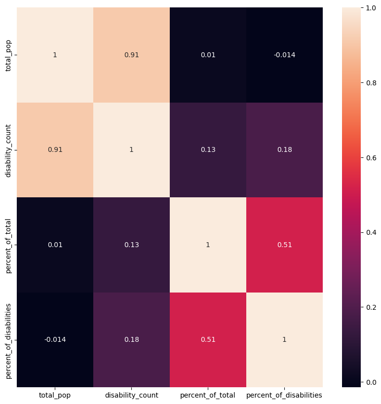

```python
#Create a subplot with matplotlib
f,ax = plt.subplots(figsize=(10,10))

# Create a correlation heatmap in seaborn of disability prevalence data set
prev_corr = sns.heatmap(prev_sub.corr(), annot = True, ax = ax)
```

- All of these numbers are going to be related. This data is just on the prevalence of disabilities. There is not useful information to gather from this.

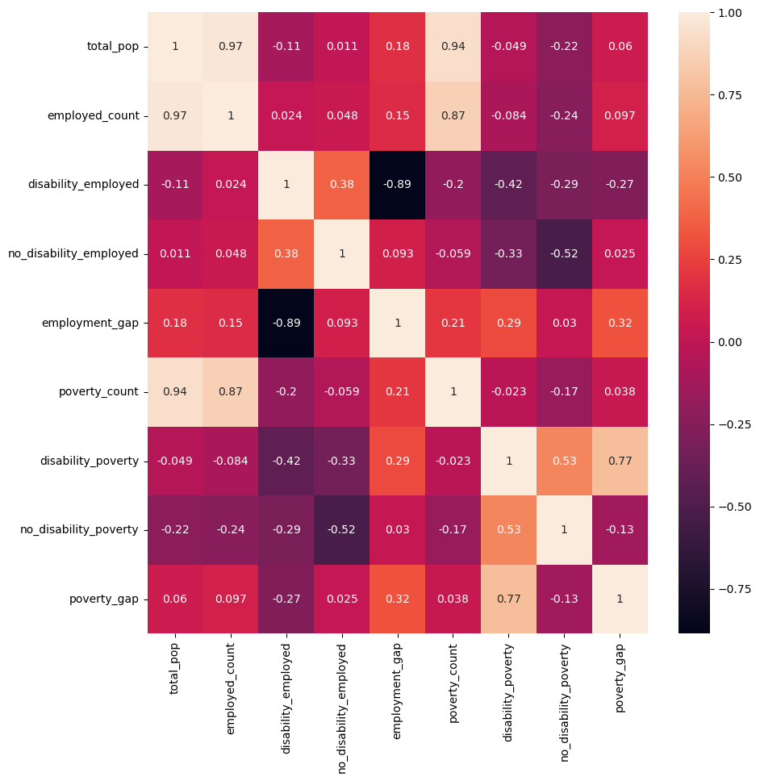

```python
#Create a subplot with matplotlib
f,ax = plt.subplots(figsize=(10,10))

# Create a correlation heatmap in seaborn of employment & poverty data set
employ_corr = sns.heatmap(employ_sub.corr(), annot = True, ax = ax)
```

Strong Positive Relationships: total_pop and employed_count, total_pop and poverty_count, employed_count and poverty_count, disability_poverty and poverty_gap, disability_poverty and no_disability_poverty

- The higher the total population, the higher the number of people employed and the higher number of people in poverty.
- The higher the number of disabled people in poverty, the higher gap there is between disabled and non-disabled people in poverty.
- The higher the number of disabled people in poverty, the higher the number of people not disabled are in poverty as well.

Moderate Positive Relationships: disability_employed and no_disability_employed, employment_gap and poverty_gap

- The higher the number of disabled people employed, the higher the number of non-disabled people employed are.
- The higher gap there is between disabled and non-disabled people in poverty, the higher gap there is between disabled and non-disabled people in employment.

Strong Negative Relationships: employment_gap and disability_employed, no_disability_employed and no_disability_poverty

- The higher the number of disabled people unemployed, the higher the employment gap between disabled and non-disabled people.
- The higher the number of non-disabled people are employed, the lower the number of non-disabled people are in poverty.

Moderate Negative Relationships: disability_employed and disability_poverty, no_disability_employed and disability_poverty

- The higher the number of disabled people unemployed, the higher the number of disabled people in poverty.
- The higher the number of disabled people in poverty, the lower the number of non-disabled people employed.

##### It sticks out that the gap between disabled and non-disabled people in both employment and poverty has a strong correlation with the number of disabled people employed and in poverty but little to no relationship with the number of non-disabled people employed and in poverty.

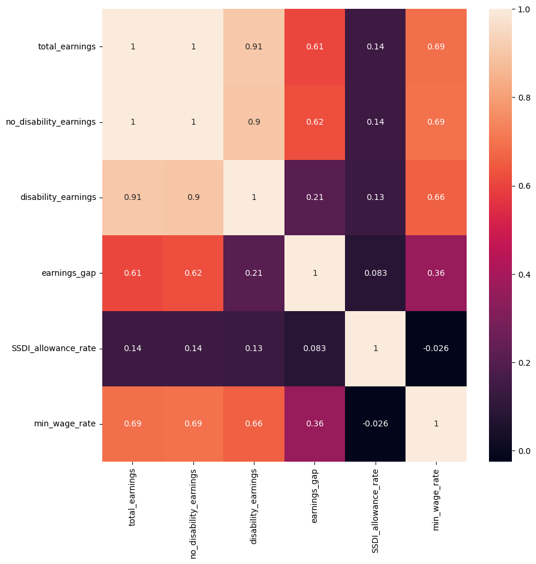

```python
#Create a subplot with matplotlib
f,ax = plt.subplots(figsize=(10,10))

# Create a correlation heatmap in seaborn of earn2 data set
earn_corr = sns.heatmap(earn_sub.corr(), annot = True, ax = ax)
```

Strong Positive Relationships: total_earnings and no_disability_earnings, total_earnings and disability_earnings, total_earnings and earnings_gap, total_earnings and min_wage_rate, no_disability_earnings and disability_earnings, no_disability_earnings and earnings_gap, no_disability_earnings and min_wage_rate, disability_earnings and min_wage_rate

- The higher the total_earnings, the higher the earnings for disabled people, non-disabled people, the gap in amount earned between disabled and non-disabled people, and minimum wage.
- The higher the gap in amount earned between disabled and non-disabled people, the higher the earnings of non-disabled people.
- The higher the minimum wage, the higher the earnings of disabled and non-disabled people.

Moderate Positive Relationships: min_wage_rate and earnings_gap

- The higher the minimum wage, the higher the gap in amount earned between disabled and non-disabled people.

##### It sticks out that there is a correlation between no_disability_earnings and earnings gap but not disability_earnings and earning_gap.

##### It sticks out that there is a correlation between min_wage_rate and earnings_gap.

## 4. Scatterplots

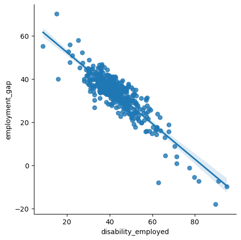

```python
#Create a scatterplot for "employment_gap" and "disability_employed" columns in seaborn
sns.lmplot(x = 'disability_employed', y = 'employment_gap', data = employ)
```

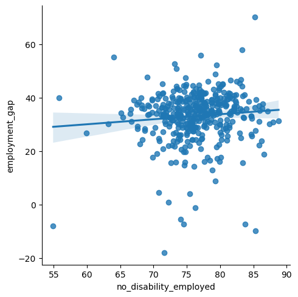

```python
#Create a scatterplot for "employment_gap" and "no_disability_employed" columns in seaborn
sns.lmplot(x = 'no_disability_employed', y = 'employment_gap', data = employ)
```

- There is a strong correlation between disability_employed and employment_gap but no correlation between no_disability_employed and employment_gap.

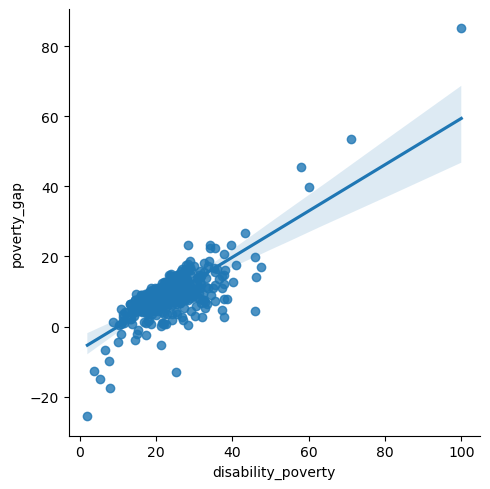

```python
#Create a scatterplot for "poverty_gap" and "disability_poverty" columns in seaborn
sns.lmplot(x = 'disability_poverty', y = 'poverty_gap', data = employ)
```

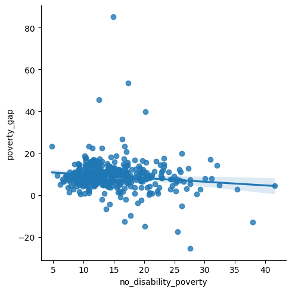

```python
#Create a scatterplot for "poverty_gap" and "no_disability_poverty" columns in seaborn
sns.lmplot(x = 'no_disability_poverty', y = 'poverty_gap', data = employ)
```

- There is a strong correlation between disability_poverty and poverty_gap and no correlation between no_disability_poverty and poverty_gap.

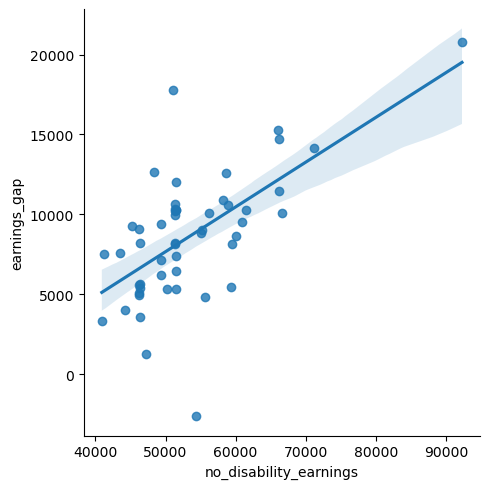

```python
#Create a scatterplot for "earnings_gap" and "no_disability_earnings" columns in seaborn
sns.lmplot(x = 'no_disability_earnings', y = 'earnings_gap', data = earn)
```

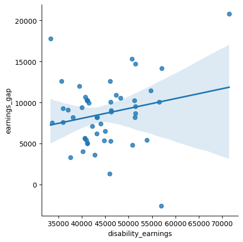

```python
#Create a scatterplot for "earnings_gap" and "disability_earnings" columns in seaborn
sns.lmplot(x = 'disability_earnings', y = 'earnings_gap', data = earn)
```

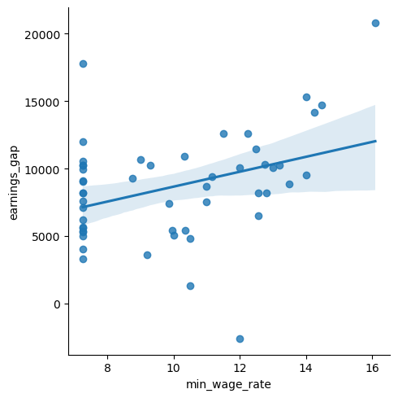

```python
#Create a scatterplot for "earnings_gap" and "min_wage_rate" columns in seaborn
sns.lmplot(x = 'min_wage_rate', y = 'earnings_gap', data = earn)
```

- There is a moderate correlation between min_wage_rate and earnings_gap.

## 5. Pair Plots

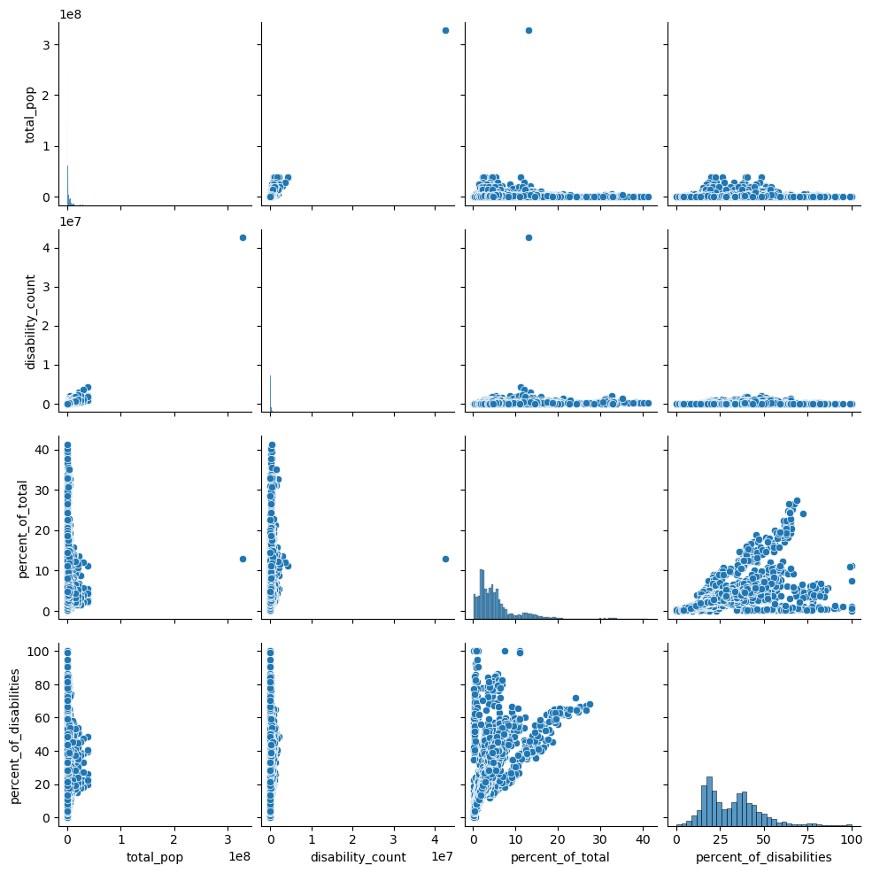

```python
#Create a pair plot for disability_prevalence data set
prev_pair = sns.pairplot(prev_sub)
```

```python
#Keep only the variables wanted for the pair plot of employment & poverty data set
employ_sub_2 = employ[['disability_employed', 'no_disability_employed', 'employment_gap', 'disability_poverty', 'no_disability_poverty', 'poverty_gap']]
```

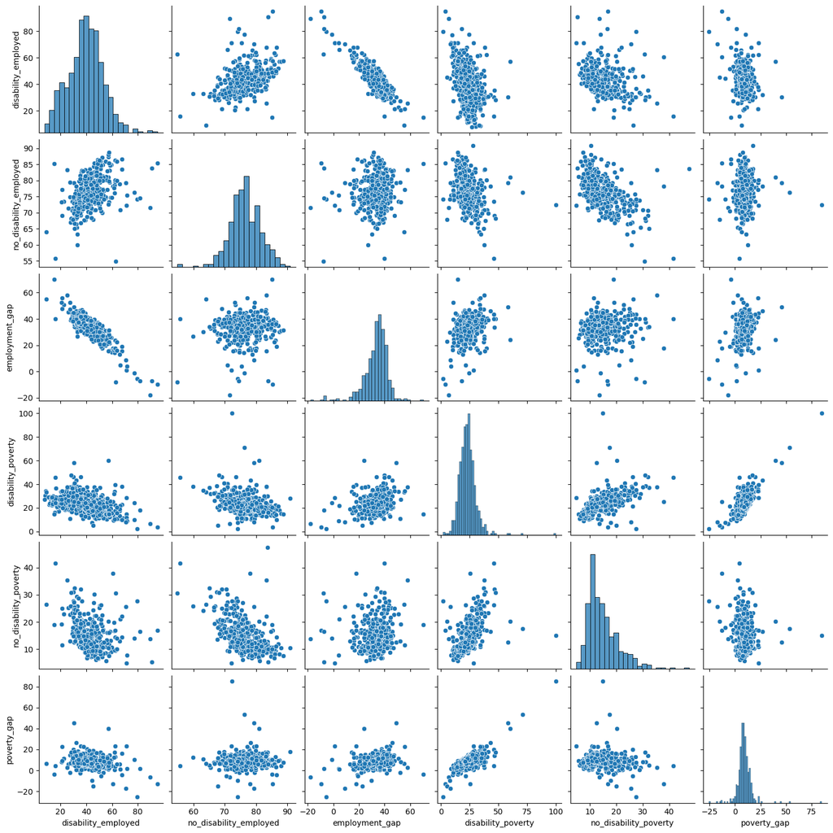

```python
#Create a pair plot for employment & poverty data set
employ_pair = sns.pairplot(employ_sub_2)
```

- The correlations between disabiled people in employment and poverty compared to the employment and poverty gaps is more apparent on this plot because they are the only ones that have more of a shape to them.

```python
#Keep only the variables wanted for the pair plot of earn2 data set
earn_sub_2 = earn[['no_disability_earnings', 'disability_earnings', 'earnings_gap', 'min_wage_rate']]
```

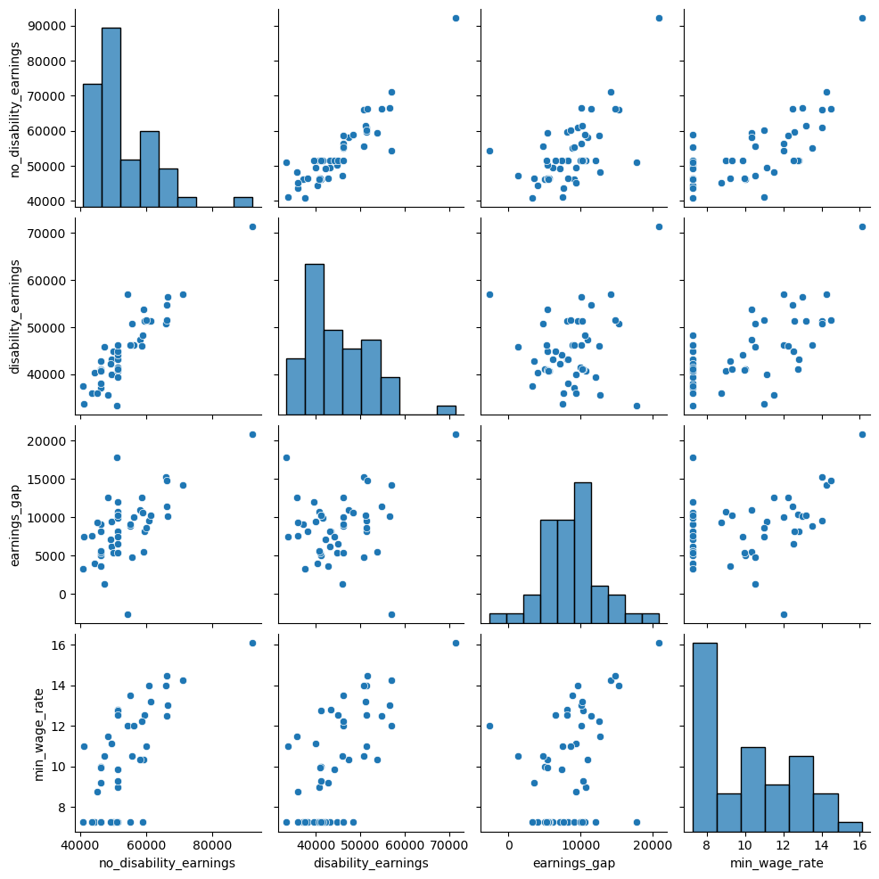

```python
#Create a pair plot for earn2 data set
earn_pair = sns.pairplot(earn_sub_2)
```

## 6. Categorical Plots

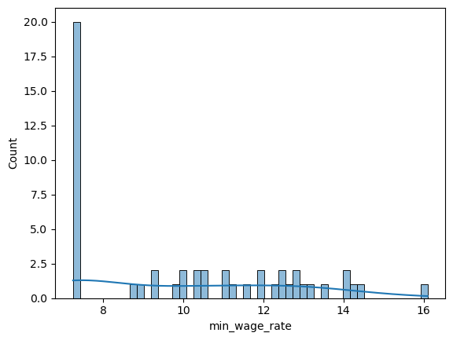

```python
#Use a histogram to visualize min_wage_rate
sns.histplot(earn['min_wage_rate'], bins = 50, kde = True)
```

```python
earn.loc[earn['min_wage_rate'] < 8, 'Min Wage Groups'] = 'Low Minimum Wage'
```

```python
earn.loc[(earn['min_wage_rate'] >= 8) & (earn['min_wage_rate'] < 12), 'Min Wage Groups'] = 'Middle Minimum Wage'
```

```python
earn.loc[earn['min_wage_rate'] >= 12 , 'Min Wage Groups'] = 'High Minimum Wage'
```

```python
earn['Min Wage Groups'].value_counts(dropna = False)
```

```
Min Wage Groups
Low Minimum Wage       20
High Minimum Wage      16
Middle Minimum Wage    15
Name: count, dtype: int64
```

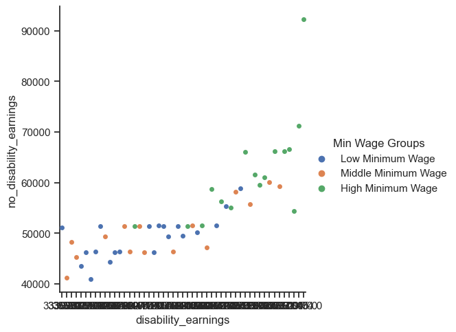

```python
#Create a categorical plot in seaborn using the Min Wage Groups created above
sns.set(style="ticks")
min_wage_groups = sns.catplot(x="disability_earnings", y="no_disability_earnings", hue="Min Wage Groups", data=earn)
```

- The highest earnings for both disabled people and non-disabled people are in states that have a higher minimum wage.

## 7. Project Questions

##### Questions from 6.1

Is there a connection between state minimum wage and poverty level of people with disabilities?

- People with disabilities earn more in states with higher minimum wages.

How does the prevalence of people with disabilities impact the community?

- The gap between disabled people and non-disabled people in employment and poverty is likely dependent on the number of disabled people employed and in poverty.

##### Additional Questions that Have Arised

- Why is there a connection between the number of disabled people employed and in poverty to the gap in employment and poverty but not one with those who are not disabled?
- How do disability categories, race, age, and gender impact the correlations made above?

## 8. Hypotheses

- The higher the number of disabled people in poverty, the higher gap there is between disabled and non-disabled people in poverty.
- The higher the number of disabled people unemployed, the higher the employment gap between disabled and non-disabled people.
- The higher the minimum wage, the higher the gap in amount earned between disabled and non-disabled people.

## 9. Extra Visuals

##### Create categorical plots on categorical variables

```python
employ_cats = employ[employ['disability_category'].isin(['Hearing', 'Vision', 'Cognitive', 'Ambulatory', 'Self-Care', 'Independent Living'])]
```

```python
employ_cats.shape
```

```
(306, 13)
```

```python
employ.shape
```

```
(714, 13)
```

```python
employ_cats.head()
```

|  | state | total_pop | disability_category | race | gender | employed_count | disability_employed | no_disability_employed | employment_gap | poverty_count | disability_poverty | no_disability_poverty | poverty_gap |
| --- | --- | --- | --- | --- | --- | --- | --- | --- | --- | --- | --- | --- | --- |
| 51 | AL | 77652 | Hearing | All | All | 40599.0 | 52.2 | NaN | NaN | 33689.0 | 16.3 | NaN | NaN |
| 52 | AK | 16161 | Hearing | All | All | 8489.0 | 52.5 | NaN | NaN | 5835.0 | 17.5 | NaN | NaN |
| 53 | AZ | 92617 | Hearing | All | All | 50667.0 | 54.7 | NaN | NaN | 43594.0 | 14.6 | NaN | NaN |
| 54 | AR | 47909 | Hearing | All | All | 25269.0 | 52.7 | NaN | NaN | 25442.0 | 17.9 | NaN | NaN |
| 55 | CA | 365481 | Hearing | All | All | 190961.0 | 52.2 | NaN | NaN | 171323.0 | 15.0 | NaN | NaN |

```python
employ.loc[employ['disability_category'] == 'Hearing', 'disability cat'] = 'hearing'
```

```python
employ.loc[employ['disability_category'] == 'Vision', 'disability cat'] = 'vision'
```

```python
employ.loc[employ['disability_category'] == 'Cognitive', 'disability cat'] = 'cognitive'
```

```python
employ.loc[employ['disability_category'] == 'Ambulatory', 'disability cat'] = 'ambulatory'
```

```python
employ.loc[employ['disability_category'] == 'Self-Care', 'disability cat'] = 'self-care'
```

```python
employ.loc[employ['disability_category'] == 'Independent Living', 'disability cat'] = 'independent-living'
```

```python
employ.loc[employ['disability_category'] == 'All', 'disability cat'] = 'all'
```

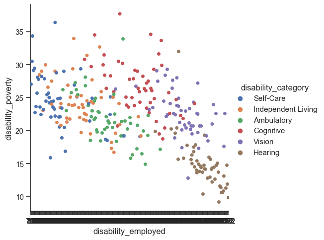

```python
#Create a categorical plot in seaborn using disability_categories created above
employ_cats_plot = sns.catplot(x="disability_employed", y="disability_poverty", hue="disability_category", data=employ_cats)
```

The poverty levels of those who are disabled is spread out with the exception of those that have a "hearing" disability that has much lower levels of poverty compared to the rest of the groups. On the other hand, the type of disability significantly impacts the likelihood of employment. Those who have "hearing" disabilities are most likely to be employed, followed by "vision", "cognitive", "ambulatory", "independent-living", and least likely to be employed being those with a "self-care" disability.

```python
employ_race = employ[employ['race'].isin(['White', 'Black', 'Asian', 'Other', 'Hispanic'])]
```

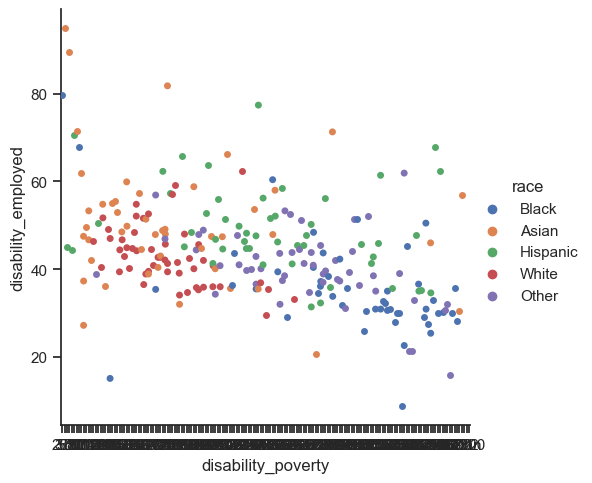

```python
#Create a categorical plot in seaborn using race created above
employ_race_plot = sns.catplot(x="disability_poverty", y="disability_employed", hue="race", data=employ_race)
```

White disabled people are less likely to be in poverty and in most states 40-60% are employed. Black disabled people are more likely to be in poverty and in most states 30-50% are employed. Asian disabled people are less likely to be in poverty and in most states 40-60% are employed but there are more outliers for this group. Hispanic diabled people are not more or less likely to be in poverty and in most states 30-70% are employed. Disabled people who do not fall under the above categories (other) are slightly more likely to be in poverty compared to white and asian disabled people and in most states 30-50% are employed.

```python
employ_gender = employ[employ['gender'].isin(['Male', 'Female'])]
```

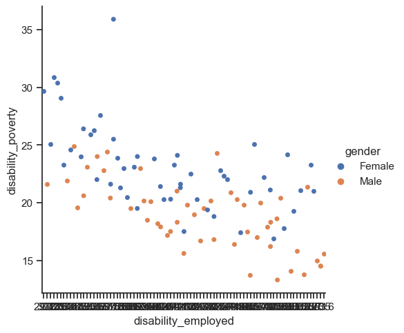

```python
#Create a categorical plot in seaborn using gender created above
employ_gender_plot = sns.catplot(x="disability_employed", y="disability_poverty", hue="gender", data=employ_gender)
```

```python
prev_gender = prev[prev['gender'].isin(['Male', 'Female'])]
```

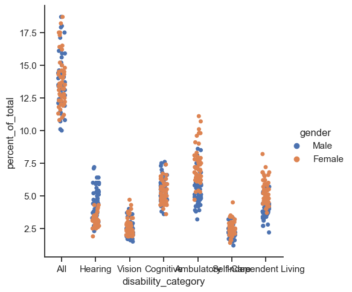

```python
#Create a categorical plot in seaborn using gender created above
prev_gender_plot = sns.catplot(x="disability_category", y="percent_of_total", hue="gender", data=prev_gender)
```

- There is a higher percentage of males with hearing disabilities.
- There is a higher percentage of females with ambulatory and independent living disabilities.
- There is about the same percentage of males and females with vision, cognitive, and self-care disabilities.
- This is hard to read. Need a clearer graph. Would like to try these in bar graphs.

```python
prev_race = prev[prev['race'].isin(['White', 'Black', 'Asian', 'Other', 'Hispanic'])]
```

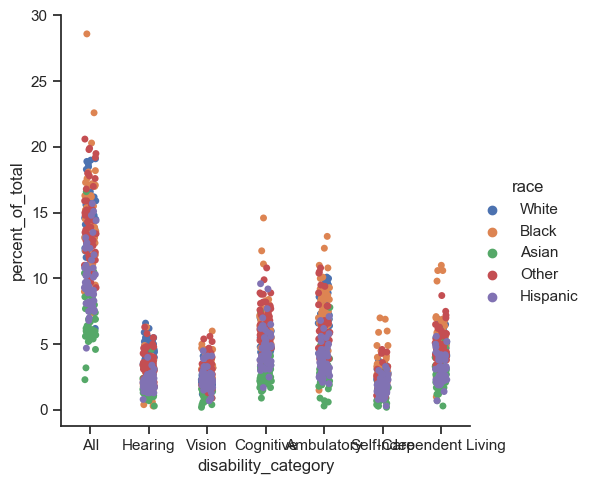

```python
#Create a categorical plot in seaborn using race created above
prev_race_plot = sns.catplot(x="disability_category", y="percent_of_total", hue="race", data=prev_race)
```

- There is a lot of overlap of data points that is hard to make out the accuracy of the data.
- From what is seen, it looks like Black people have the highest percentage of people with disabilities with the exception of hearing disabilities and Asian people have the lowest percentage of people with disabilities.
- This leads to questions related to how people qualify for disabilities and the bias attached.

```python
#Group by percent of total and race
prev_race2=prev_race.groupby(['disability_category','race']).size().unstack()
```

```python
#Sort
prev_race2 = prev_race2.loc[prev_race2.sum(axis=1).sort_values(ascending = True).index]
```

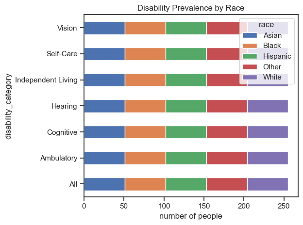

```python
#create bar graph
prev_race_bar = prev_race2.plot.barh(stacked = True, title = 'Disability Prevalence by Race', xlabel = 'number of people')
plt.tight_layout()
```

- failed attempt to show disability prevalence by race. Need to try something different.

```python
prev_age = prev[prev['age_group'].isin(['Under 5', '5-17 Years', '18-64 Years', '65+ Years'])]
```

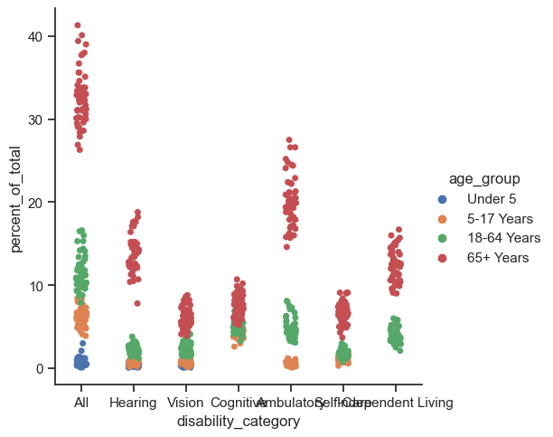

```python
#Create a categorical plot in seaborn using age created above
prev_race_plot = sns.catplot(x="disability_category", y="percent_of_total", hue="age_group", data=prev_age)
```

- There is a lot of overlap of data points that is hard to make out the accuracy of the data.
- From what can be seen, there is a significantly higher percentage of people over 65 with disabilities in hearing, ambulatory, and independent living which makes sense considering as people who are 65+ are more likely to devlop issues with hearing, moving, and living independently.